# Ejercicio 2: municipios por indicadores socioeconómicos (clustering + PCA)

SESIÓN 18 — APRENDIZAJE NO SUPERVISADO

Autor/a

Jorge Juvenal Campos Ferreira — TC2001B.601

Fecha de publicación

24 de mayo de 2026

```r
options(scipen = 999)
```

Contexto de política pública:

Tenemos 500 municipios de México descritos por indicadores de pobreza, carencias, ingreso, ruralidad, conectividad y marginación. NO hay una etiqueta oficial de “tipo de municipio”. Queremos AGRUPARLOS en perfiles socioeconómicos para diseñar políticas diferenciadas: no tiene sentido aplicar la misma intervención a un municipio urbano bien conectado que a uno rural marginado.

Esto es aprendizaje NO supervisado: no hay variable objetivo ni partición entrenamiento/prueba. El objetivo es descubrir e interpretar estructura.

```r
# Librerías ----
library(tidyverse)
library(tidymodels)
library(factoextra)
library(cluster)
```

```r
tidymodels::tidymodels_prefer()
```

## 1. CARGA Y PREPARACIÓN DE LOS DATOS

```r
# Cargamos los 500 municipios. clave_municipio es solo un identificador
# (MUN001, MUN002, ...): NO es un indicador y debe removerse antes de
# cualquier cálculo de distancia (si no, el "id" entraría como variable).
municipios <- read_csv("datos.csv") %>%
  select(-clave_municipio)
```

```r
glimpse(municipios)
```

```
Rows: 500
Columns: 9
$ pct_pobreza            <dbl> 65.34, 31.29, 17.24, 51.65, 69.03, 61.95, 24.68…
$ pct_carencia_educativa <dbl> 42.63, 16.54, 14.68, 27.46, 46.05, 41.58, 9.02,…
$ pct_carencia_salud     <dbl> 58.01, 12.76, 21.15, 36.38, 56.87, 45.41, 9.78,…
$ ingreso_promedio_mxn   <dbl> 7710, 12124, 15009, 6337, 5829, 5758, 13464, 16…
$ pct_poblacion_rural    <dbl> 73.40, 17.27, 5.42, 51.58, 73.51, 61.39, 21.04,…
$ pct_acceso_internet    <dbl> 24.27, 79.36, 76.31, 55.00, 13.42, 27.61, 84.09…
$ densidad_pob_km2       <dbl> 45.28, 71.31, 1061.85, 111.04, 76.95, 1.00, 915…
$ tasa_alfabetizacion    <dbl> 79.67, 99.96, 97.55, 85.80, 78.07, 85.71, 100.0…
$ grado_marginacion_idx  <dbl> 1.16, 0.59, 0.36, 0.90, 1.23, 1.20, 0.41, 0.47,…
```

```r
summary(municipios)
```

```
  pct_pobreza    pct_carencia_educativa pct_carencia_salud ingreso_promedio_mxn
 Min.   : 8.56   Min.   : 1.00          Min.   : 1.00      Min.   : 1500
 1st Qu.:31.60   1st Qu.:19.29          1st Qu.:22.88      1st Qu.: 4410
 Median :46.94   Median :33.26          Median :38.16      Median : 6936
 Mean   :49.02   Mean   :35.42          Mean   :39.32      Mean   : 8050
 3rd Qu.:65.42   3rd Qu.:51.72          3rd Qu.:56.22      3rd Qu.:11414
 Max.   :99.00   Max.   :76.95          Max.   :80.78      Max.   :19280
                                                           NA's   :20
 pct_poblacion_rural pct_acceso_internet densidad_pob_km2  tasa_alfabetizacion
 Min.   :  0.00      Min.   : 1.00       Min.   :   1.00   Min.   : 61.07
 1st Qu.: 23.70      1st Qu.:24.04       1st Qu.:  54.97   1st Qu.: 77.41
 Median : 43.29      Median :45.49       Median : 172.48   Median : 87.10
 Mean   : 49.11      Mean   :45.38       Mean   : 428.54   Mean   : 85.32
 3rd Qu.: 76.68      3rd Qu.:67.25       3rd Qu.: 567.30   3rd Qu.: 94.20
 Max.   :100.00      Max.   :99.00       Max.   :2504.16   Max.   :100.00

 grado_marginacion_idx
 Min.   :0.140
 1st Qu.:0.550
 Median :0.890
 Mean   :0.943
 3rd Qu.:1.302
 Max.   :1.750
```

```r
# NAs por columna: esperamos faltantes en ingreso_promedio_mxn (~4%).
# Los algoritmos de distancia y el PCA NO toleran NAs: hay que resolverlos.
colSums(is.na(municipios))
```

```
           pct_pobreza pct_carencia_educativa     pct_carencia_salud
                     0                      0                      0
  ingreso_promedio_mxn    pct_poblacion_rural    pct_acceso_internet
                    20                      0                      0
      densidad_pob_km2    tasa_alfabetizacion  grado_marginacion_idx
                     0                      0                      0
```

```r
# Colinealidad: grado_marginacion_idx se construye a partir de la pobreza y
# la carencia educativa, así que estará muy correlacionado con ellas.
# La dejamos (el PCA la absorbe en componentes ortogonales) pero la
# señalamos para interpretarla con cuidado.
matriz_cor <- municipios %>%
  cor(use = "complete.obs") %>%
  round(2)
matriz_cor[, c("pct_pobreza", "pct_carencia_educativa",
               "grado_marginacion_idx")]
```

```
                       pct_pobreza pct_carencia_educativa grado_marginacion_idx
pct_pobreza                   1.00                   0.93                  0.98
pct_carencia_educativa        0.93                   1.00                  0.97
pct_carencia_salud            0.91                   0.92                  0.93
ingreso_promedio_mxn         -0.86                  -0.87                 -0.88
pct_poblacion_rural           0.92                   0.92                  0.93
pct_acceso_internet          -0.91                  -0.92                 -0.92
densidad_pob_km2             -0.75                  -0.74                 -0.75
tasa_alfabetizacion          -0.89                  -0.89                 -0.90
grado_marginacion_idx         0.98                   0.97                  1.00
```

IMPUTACIÓN Y NORMALIZACIÓN

```r
# step_impute_median: rellena los NAs de ingreso con la MEDIANA. Preferimos
# la mediana sobre la media porque el ingreso es asimétrico (unos pocos
# municipios ricos inflan la media); la mediana es más robusta.
#
# ¿POR QUÉ NORMALIZAR (z-score) ES INDISPENSABLE?
# Los porcentajes van de 0 a 100, el ingreso a decenas de miles de pesos y
# la densidad puede ser enorme. El PCA (que maximiza varianza) y el
# clustering (que mide distancias) son SENSIBLES A LA ESCALA: sin
# normalizar, ingreso_promedio_mxn y densidad_pob_km2 dominarían por sus
# números grandes, y los grupos reflejarían las unidades, no el perfil
# socioeconómico. El z-score deja toda variable con media 0 y desviación 1,
# de modo que pesen por igual.
receta_municipios <- recipe(~ ., data = municipios) %>%
  step_impute_median(all_numeric_predictors()) %>%
  step_normalize(all_numeric_predictors())
```

```r
# prep() aprende la mediana de imputación y los parámetros de escala;
# bake() devuelve la matriz lista (imputada y normalizada).
municipios_norm <- receta_municipios %>%
  prep() %>%
  bake(new_data = NULL)
```

```r
# Verificación: media ~0, desviación ~1 y sin NAs.
municipios_norm %>%
  summarise(across(everything(), list(media = mean, desv = sd))) %>%
  glimpse()
```

```
Rows: 1
Columns: 18
$ pct_pobreza_media            <dbl> -0.000000000000001041611
$ pct_pobreza_desv             <dbl> 1
$ pct_carencia_educativa_media <dbl> -0.000000000000000726974
$ pct_carencia_educativa_desv  <dbl> 1
$ pct_carencia_salud_media     <dbl> 0.00000000000000006683543
$ pct_carencia_salud_desv      <dbl> 1
$ ingreso_promedio_mxn_media   <dbl> -0.00000000000000002753353
$ ingreso_promedio_mxn_desv    <dbl> 1
$ pct_poblacion_rural_media    <dbl> -0.000000000000001590728
$ pct_poblacion_rural_desv     <dbl> 1
$ pct_acceso_internet_media    <dbl> -0.0000000000000005571099
$ pct_acceso_internet_desv     <dbl> 1
$ densidad_pob_km2_media       <dbl> -0.0000000000000006975531
$ densidad_pob_km2_desv        <dbl> 1
$ tasa_alfabetizacion_media    <dbl> -0.000000000000007015055
$ tasa_alfabetizacion_desv     <dbl> 1
$ grado_marginacion_idx_media  <dbl> 0.000000000000002789768
$ grado_marginacion_idx_desv   <dbl> 1
```

```r
colSums(is.na(municipios_norm))
```

```
           pct_pobreza pct_carencia_educativa     pct_carencia_salud
                     0                      0                      0
  ingreso_promedio_mxn    pct_poblacion_rural    pct_acceso_internet
                     0                      0                      0
      densidad_pob_km2    tasa_alfabetizacion  grado_marginacion_idx
                     0                      0                      0
```

## 2. PCA — ANÁLISIS DE COMPONENTES PRINCIPALES

Reducimos los 9 indicadores a unos pocos ejes (componentes) que concentran la varianza, para visualizar a los 500 municipios en un plano y entender qué indicadores “se mueven juntos”. Ya normalizamos, así que prcomp() no vuelve a escalar.

```r
pca_municipios <- prcomp(municipios_norm, center = FALSE, scale. = FALSE)
```

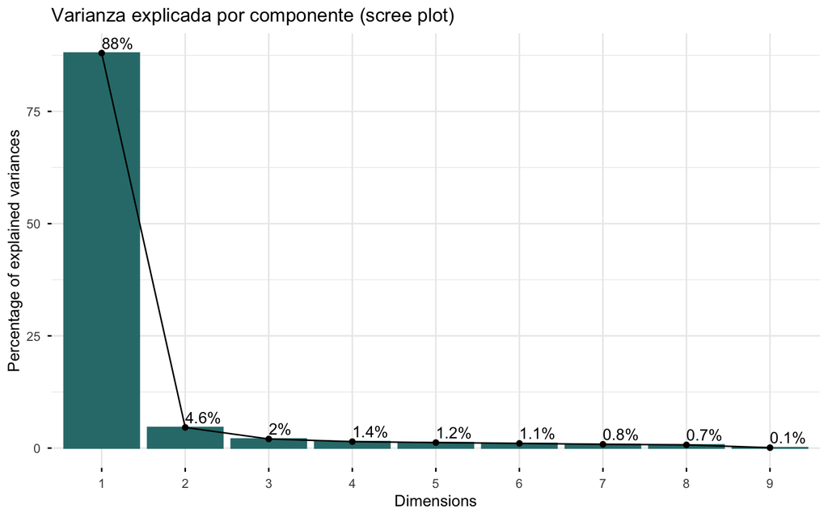

```r
# Scree plot: varianza explicada por componente. Buscamos el "codo" para
# decidir cuántas componentes resumen lo esencial.
fviz_eig(pca_municipios, addlabels = TRUE,
         barfill = "#2d7a7a", barcolor = "#2d7a7a",
         main = "Varianza explicada por componente (scree plot)")
```

```r
# Varianza explicada en números (proporción y acumulada).
varianza_explicada <- summary(pca_municipios)$importance
varianza_explicada[, 1:5]
```

```
                            PC1       PC2       PC3       PC4     PC5
Standard deviation     2.814331 0.6433323 0.4275611 0.3598125 0.33202
Proportion of Variance 0.880050 0.0459900 0.0203100 0.0143900 0.01225
Cumulative Proportion  0.880050 0.9260400 0.9463500 0.9607300 0.97298
```

```r
# Cargas (rotation): peso de cada indicador en PC1 y PC2.
cargas <- pca_municipios$rotation[, 1:2] %>%
  round(2)
cargas
```

```
                         PC1   PC2
pct_pobreza            -0.34  0.13
pct_carencia_educativa -0.34  0.14
pct_carencia_salud     -0.34  0.15
ingreso_promedio_mxn    0.32  0.30
pct_poblacion_rural    -0.34  0.11
pct_acceso_internet     0.34  0.01
densidad_pob_km2        0.29  0.83
tasa_alfabetizacion     0.33 -0.36
grado_marginacion_idx  -0.35  0.14
```

INTERPRETACIÓN DE LAS PRIMERAS COMPONENTES (leer la tabla ‘cargas’):

- PC1 captura el GRADIENTE DE DESARROLLO/MARGINACIÓN, el contraste socioeconómico dominante: de un lado pobreza, carencias, ruralidad y grado de marginación (que cargan juntos por su colinealidad); del otro, ingreso, acceso a internet y alfabetización. Un municipio con PC1 alto en un sentido es marginado; en el opuesto, desarrollado.
- PC2 recoge un segundo eje, típicamente ligado a la RURALIDAD/DENSIDAD independiente del nivel de marginación: separa municipios densos y urbanos de los dispersos y rurales con niveles de carencia parecidos. La lectura exacta depende de los signos en ‘cargas’; el alumno debe describir el contraste real observado.

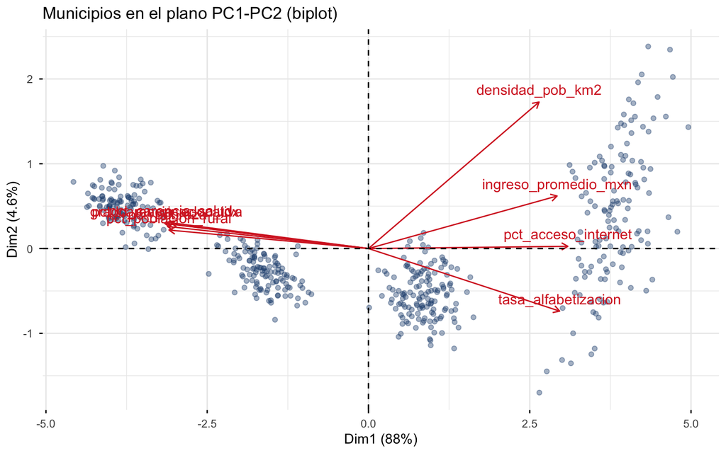

```r
# Proyección de los 500 municipios en PC1-PC2 (biplot). Las flechas de
# pct_pobreza, grado_marginacion_idx y pct_carencia_educativa deberían salir
# casi paralelas, mostrando visualmente su colinealidad.
fviz_pca_biplot(pca_municipios,
                label = "var", col.var = "#d62828",
                col.ind = "#1e4c7d", alpha.ind = 0.4,
                title = "Municipios en el plano PC1-PC2 (biplot)")
```

## 3. ELECCIÓN DEL NÚMERO DE GRUPOS (k)

Necesitamos fijar k para k-means. Lo decidimos con dos diagnósticos.

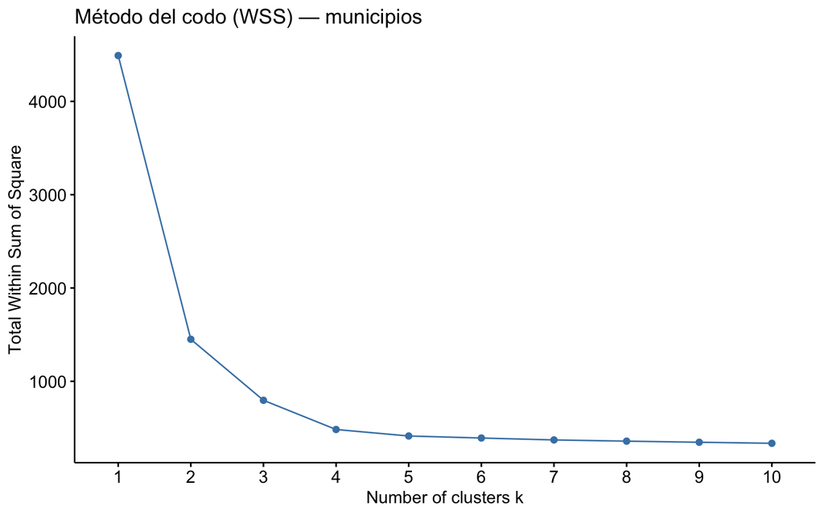

```r
# Método del codo (WSS): al subir k, la suma de cuadrados dentro de los
# grupos siempre baja; buscamos el codo donde el descenso se vuelve
# marginal. Ese k es un buen candidato.
set.seed(2026)
fviz_nbclust(municipios_norm, kmeans, method = "wss", nstart = 20) +
  labs(title = "Método del codo (WSS) — municipios")
```

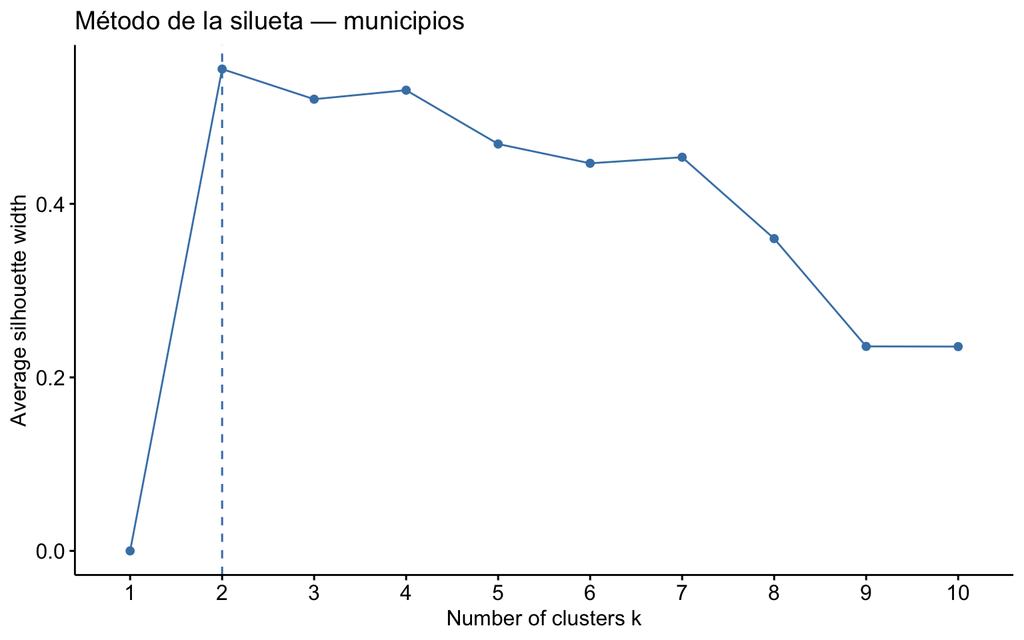

```r
# Método de la silueta: mide qué tan bien separados quedan los grupos para
# cada k. El k con silueta promedio MÁS ALTA es el preferido; suele desempatar
# cuando el codo no es claro.
set.seed(2026)
fviz_nbclust(municipios_norm, kmeans, method = "silhouette", nstart = 20) +
  labs(title = "Método de la silueta — municipios")
```

```r
# Sustantivamente esperamos del orden de 4 perfiles de municipio (urbano
# desarrollado, urbano medio, rural en transición, rural marginado). Tras
# leer codo y silueta elegimos k = 4.
k_elegido <- 4
```

## 4. K-MEANS CON EL k ELEGIDO

```r
#
# nstart = 25: k-means depende de la inicialización aleatoria; con 25
# arranques nos quedamos con la mejor solución y evitamos óptimos locales.
set.seed(2026)
km_municipios <- kmeans(municipios_norm, centers = k_elegido, nstart = 25)
```

```r
# Tamaño de cada grupo (número de municipios).
km_municipios$size
```

```
[1] 142 110 120 128
```

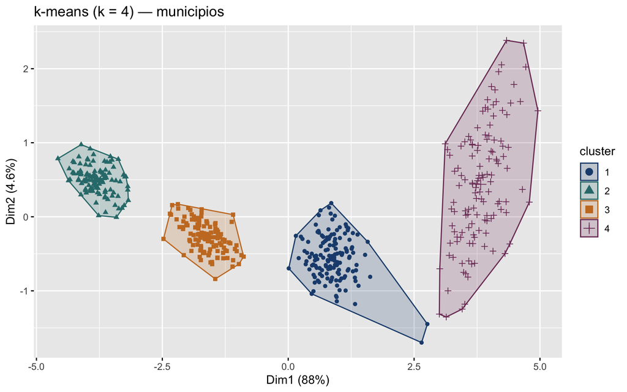

```r
# Visualización de los clusters proyectados en PC1-PC2.
fviz_cluster(km_municipios, data = municipios_norm,
             geom = "point", ellipse.type = "convex",
             palette = c("#1e4c7d", "#2d7a7a", "#c97b2a", "#7d3c66"),
             main = paste0("k-means (k = ", k_elegido, ") — municipios"))
```

```r
# PERFILADO DE LOS GRUPOS:
# Para nombrar cada grupo calculamos las medias de los indicadores
# ORIGINALES (en sus unidades: %, MXN, hab/km²) por cluster. Así leemos
# directamente el perfil socioeconómico de cada grupo.
municipios_perfilados <- municipios %>%
  mutate(cluster = factor(km_municipios$cluster))
```

```r
perfil_clusters <- municipios_perfilados %>%
  group_by(cluster) %>%
  summarise(across(everything(), mean), n = n()) %>%
  ungroup()
perfil_clusters
```

```
# A tibble: 4 × 11
  cluster pct_pobreza pct_carencia_educativa pct_carencia_salud
  <fct>         <dbl>                  <dbl>              <dbl>
1 1              42.1                   27.9               31.6
2 2              78.9                   61.4               65.5
3 3              58.6                   45.5               49.7
4 4              22.0                   12.0               15.7
# ℹ 7 more variables: ingreso_promedio_mxn <dbl>, pct_poblacion_rural <dbl>,
#   pct_acceso_internet <dbl>, densidad_pob_km2 <dbl>,
#   tasa_alfabetizacion <dbl>, grado_marginacion_idx <dbl>, n <int>
```

INTERPRETACIÓN (leer ‘perfil_clusters’): Comparando las medias por grupo se reconocen perfiles de política pública, por ejemplo:

- municipios urbanos desarrollados: ingreso y acceso a internet altos, pobreza y marginación bajas, poca población rural;
- municipios urbanos medios: indicadores intermedios;
- municipios rurales en transición: ruralidad alta pero con avances en conectividad/alfabetización;
- municipios rurales marginados: pobreza, carencias y marginación altas, ingreso y acceso a internet bajos. El alumno debe etiquetar cada grupo según las cifras reales observadas y pensar qué intervención prioritaria correspondería a cada uno.

## 5. CLUSTERING JERÁRQUICO (comparación)

El jerárquico construye un árbol fusionando municipios por cercanía; lo cortamos al número de grupos deseado. Sirve para contrastar con k-means.

```r
# Distancias euclidianas entre los 500 municipios normalizados.
dist_municipios <- dist(municipios_norm, method = "euclidean")
```

```r
# Ward (ward.D2): produce grupos compactos y de tamaño comparable, lo que
# facilita la comparación contra k-means.
hc_municipios <- hclust(dist_municipios, method = "ward.D2")
```

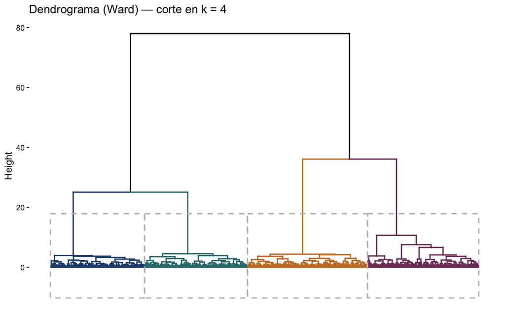

```r
# Dendrograma coloreado al mismo k que k-means.
fviz_dend(hc_municipios, k = k_elegido,
          k_colors = c("#1e4c7d", "#2d7a7a", "#c97b2a", "#7d3c66"),
          show_labels = FALSE, rect = TRUE,
          main = paste0("Dendrograma (Ward) — corte en k = ",
                        k_elegido))
```

```r
# Cortamos en k grupos.
grupos_hc <- cutree(hc_municipios, k = k_elegido)
```

```r
# COMPARACIÓN k-means vs jerárquico:
# Las etiquetas de grupo son arbitrarias entre métodos, así que NO miramos
# la diagonal: revisamos si cada grupo de un método cae mayormente en UN
# grupo del otro. Si la correspondencia es fuerte, ambos métodos descubren
# los mismos perfiles de municipio y eso da robustez a la segmentación que
# llevaríamos al diseño de política.
table(kmeans = km_municipios$cluster, jerarquico = grupos_hc)
```

```
      jerarquico
kmeans   1   2   3   4
     1   0   2 140   0
     2   0   0   0 110
     3 120   0   0   0
     4   0 128   0   0
```